# Pomiar i prognoza pandemii COVID-19 w Polsce w czasie rzeczywistym

## Wprowadzenie

Na dzień dzisiejszy widziałem niewiele analiz zorientowanych na predykcję dynamiki epidemiologicznej pandemii COVID-19 w Polsce. Te, które widziałem, opierają się na dopasowaniu funkcji wykładniczych do liczby zgłaszanych przypadków. Takie podejście ma co najmniej dwie poważne wady. Pierwsza wada polega na tym, że faza wykładnicza epidemii utrzymuje się tylko na początku, gdy większość populacji jest nadal podatna na zakażenie. Przez to analiz takich nie można wykorzystać do predykcji tego, kiedy krzywa epidemiologiczna zwolni i osiągnie maksimum liczby zachorowań. Drugą wadą jest to, że ponieważ przebieg choroby COVID-19 jest najprawdopodobniej za bezobjawowy w dużej części populacji, liczba zgłaszanych przypadków będzie zależała nie tylko od dynamiki epidemiologicznej, ale także od proporcji populacji, która jest testowana na obecność wirusa. Dlatego możliwość przewidywania skutków epidemii w Polsce, jak w każdym innym kraju, wymaga podejścia statystycznego, które przy absolutnym minimum jest w stanie uporać się z tymi dwoma problemami.

W tym raporcie postanowiłem posłużyć się podejściem podobnym do wypracowanego przez moich [kolegów z Uniwersytetu w Bernie](https://ispmbern.github.io/covid-19/swiss-epidemic-model/), które opiera się na idei dopasowania [modelu epidemiologicznego typu SEIR](https://en.wikipedia.org/wiki/Compartmental_models_in_epidemiology#The_SEIR_model) do liczby zgłaszanych zgonów u pacjentów COVID-19, argumentując, że takie przypadki mają małe prawdopodobieństwo pominięcia. Dopasowuję ten model do oficjalnych danych Ministerstwa Zdrowia, zebranych i upublicznionych przez pana [Michała Rogalskiego](https://twitter.com/micalrg) pod [tym linkiem](https://docs.google.com/spreadsheets/d/1ierEhD6gcq51HAm433knjnVwey4ZE5DCnu1bW7PRG3E/htmlview#gid=1400401584). Dane te wskazują, że pierwszy zgłoszony i potwierdzony przypadek zakażenia SARS-CoV-2 w Polsce miał miejsce 4 marca. Polski rząd wprowadził pierwsze ograniczenia (tzw. stan zagrożenia epidemicznego) 10 dni później, 14 marca. Korzystając z tych narzędzi, starałem się wykorzystać podejście oparte na modelowaniu matematycznym, aby uzyskać wgląd w czas początku polskiej epidemii, oszacować odsetek niewykrytych przypadków zakażenia na 26/03 oraz przewidzieć różne scenariusze epidemii w zależności od skuteczności działań ograniczeń rządowych. Na koniec otwarcie dyskutuję również ograniczenia mojego podejścia i komentuję ograniczenia modelowania matematycznego w epidemiologii. W załączeniu do raportu przedstawiam [**kod napisany za pomocą R MarkdownMarkdown**](https://github.com/rmostowy/rmostowy.github.io/blob/master/covid-19/code/v1/data.zip), który każdy może pobrać i wykorzystać do dalszych analiz.

## Metodologia

Analiza opiera się na matematycznym modelu epidemiologicznym [typu SEIR](https://en.wikipedia.org/wiki/Compartmental_models_in_epidemiology#The_SEIR_model), z istotną różnicą, że model dodatkowo uwzględnia osoby, które są hospitalizowane, przyjmowane na oddział intensywnej terapii, oraz które umierają od infekcji. Model można zwięźle podsumować następującym diagramem.

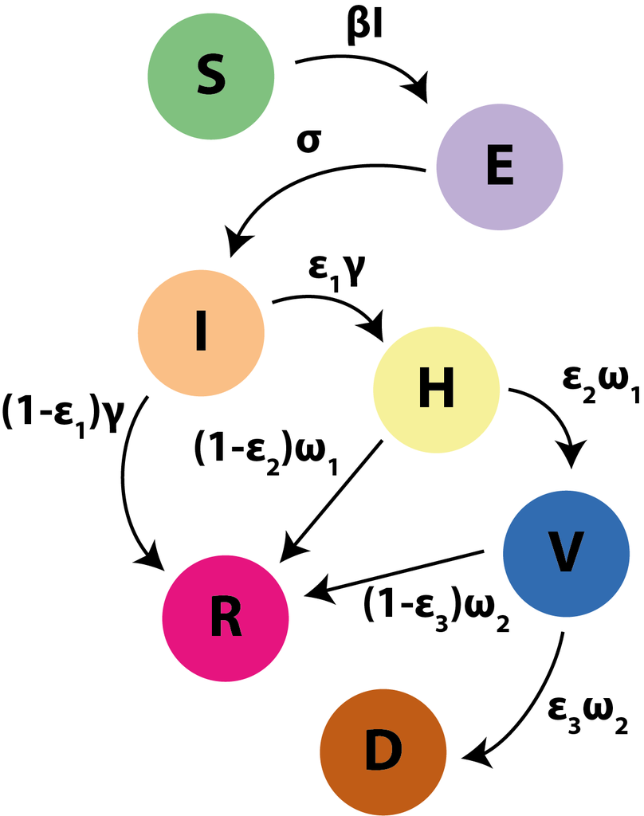

**Rycina 1. Podsumowanie modelu epidemiologicznego użytego w analizje** Podatni na infekcję (S) są narażeni (E) kiedy wchodzą w kontakt z osobą zakaźną (I) ze współczynnikiem $\beta I$, a narażeni stają się zakaźni ze współczynnikiem $\sigma$. Zakażeni zdrowieją (R) ze współczynnikiem $(1-\epsilon_1)\gamma$ i są poddawani hospitalizacji (H) ze współczynnikiem $\epsilon_1\gamma$. Hospitalizowani zdrowieją ze współczynnikiem $(1-\epsilon_2)\omega_1$ i są przyjmowani na oddział intensywnej terapii (V) ze współczynnikiem $\epsilon_2\omega_1$. Pacjenci oddziału intensywnej terapii zdrowieją ze współczynnikiem $(1-\epsilon_3)\omega_2$ i umierają (D) ze współczynnikiem $\epsilon_3\omega_2$. W tym modelu $\beta=R_0\gamma/N$, gdzie $R_0$ to bazowy współczynnik reprodukcji a $N$ to wielkość populacji. Epidemia zaczyna się w czasie $t_{case}-T_{seed}$, gdzie $t_{case}$ to data pierwszego potwierdzonego zakażenia (04/03) a $T_\text{seed}$ to odstęp czasu między pierwszym potwierdzonym zakażeniem a pierwszym rzeczywistym zakażeniem. W dniu $t_{case}+10$, czyli 14/03, wprowadzone są rządowe interwencje i bazowy współczynnik reprodukcji zostaje zredukowany do $\kappa R_0$, gdzie $\kappa\in[0,1]$.

Współczynniki w powyższym modelu zostały obliczone na podstawie założonych parametrów modelu, których wartości przyjąłem na podstawie literatury.

| Parametr | Wartość | Źródło |
| --- | --- | --- |
| Wielkość populacji RP | 38 386 000 | [Główny Urząd Statystyczny (GUS) Office](https://stat.gov.pl/download/gfx/portalinformacyjny/pl/defaultaktualnosci/5468/6/26/1/ludnosc._stan_i_struktura_oraz_ruch_naturalny_w_przekroju_terytorialnym_n… |
| Interwał seryjny (okres przejściowy+zakaźny) | 7.5 dnia | [Li et al.](https://doi.org/10.1056/NEJMoa2001316) |
| Czas trwania pobytu w szpitalu w przypadku lekkich i ciężkich przypadków | 8 dni | Przyjęte na podstawie [Imperial College COVID-19 Response Team: Report 9](https://www.imperial.ac.uk/media/imperial-college/medicine/sph/ide/gida-fellowships/Imperial-College-COVID19-NPI-modelling-16-… |
| Dodatkowy czas pobytu w szpitalu w przypadkach krytycznych | 8 dni | Przyjęte na podstawie [Imperial College COVID-19 Response Team: Report 9](https://www.imperial.ac.uk/media/imperial-college/medicine/sph/ide/gida-fellowships/Imperial-College-COVID19-NPI-modelling-16-… |
| Proporcja przypadków hospitalizowanych | 5% | Przyjęte na podstawie [Imperial College COVID-19 Response Team: Report 9](https://www.imperial.ac.uk/media/imperial-college/medicine/sph/ide/gida-fellowships/Imperial-College-COVID19-NPI-modelling-16-… |
| Proporcja przypadków krytycznych | 2.5% | Przyjęte na podstawie [Imperial College COVID-19 Response Team: Report 9](https://www.imperial.ac.uk/media/imperial-college/medicine/sph/ide/gida-fellowships/Imperial-College-COVID19-NPI-modelling-16-… |
| Śmiertelność | 1.25% | Przyjęte na podstawie [Imperial College COVID-19 Response Team: Report 9](https://www.imperial.ac.uk/media/imperial-college/medicine/sph/ide/gida-fellowships/Imperial-College-COVID19-NPI-modelling-16-… |
| Bazowy współczynnik reprodukcji $R_0$ | 2.0-2.6 | Przyjęte na podstawie [Imperial College COVID-19 Response Team: Report 9](https://www.imperial.ac.uk/media/imperial-college/medicine/sph/ide/gida-fellowships/Imperial-College-COVID19-NPI-modelling-16-… |

**Tabela 1. Parametry modelu epidemiologicznego COVID-19.** Model jest dopasowany do danych przy użyciu podejścia opartego na maksymalnym prawdopodobieństwie, poprzez porównanie przewidywanej liczby zgonów z zaobserwowaną liczbą zgonów. Zakłada się, że dzienna liczba zgonów jest zgodna z rozkładem Poissona. Używając wartości parametrów założonych powyżej, szacujemy wartości $T_\text{seed}$ oraz $\kappa$, które najlepiej wyjaśniają zaobserwowane dane przy założonym modelu. Rozważamy cztery różne wartości $R_0=\{2.0, 2.2, 2.4, 2.6\}$.

## Wyniki

### 0. Kluczowy parametr $\kappa$ (kappa)

Z punktu widzenia predykcji modelu, parametrem mającym największy wpływ na impakt pandemii COVID-19 w Polsce jest $\kappa$. Jego wartość odzwierciedla skuteczność interwencji dystansowania społecznego wprowadzonych rzez rząd polski poprzez wpływ na bazowy współczynnik reprodukcji $R_0$ (reprezentującym ilość drugorzędnych zakażeń przez zakaźną osobę w pełni podatnej populacji; epidemia się rozwija gdy $R_0>1$ i gaśnie gdy $R_0<1$). Konkretniej mówiąc, $\kappa=1$ odpowiada sytuacji, w której interwencje nie miały żadnego wpływu na transmisję wirusa w populacji ($R_0$ niezmienione), natomiast $\kappa=0$ odpowiada sytuacji, w której interwencje uniemożliwiły jakiekolwek nowe zakażenia ($R_0=0$). Te obie sytuacje są hipotetyczne i mało prawdopodobne; w rzeczywistości $\kappa$ będzie przyjmować wartość gdzieś między 1 a 0. Celem zaproponowanego podejścia jest oszacowanie wartości parametru $\kappa$, jendak jak na dzień 26/03/2020 nie mamy dostatecznej ilości danych, żeby to zrobić. Dla każdej z założonych wartości $R_0$, szacowana wartość $\kappa$ była blisko 1, ale wynik ten nie był istotny statystycznie (95% przedział ufności: [0,1]).

### 1. Kiedy polska epidemia się zaczęła naprawdę?

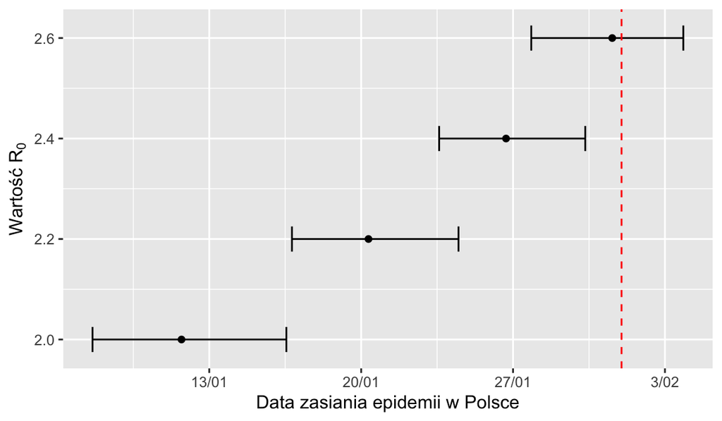

**Rycina 2. Szacowany czas zasiania epidemii w Polsce.** Widełki pokazują 95% przedział nieufności w szacowanym czasie, $T_\text{seed}$, przetłumaczonych na daty dla zakładanej wartości $R_0$. Przerywana linia pionowa reprezentuje początek lutego.

### 2. Ile mamy obecnie zakażonych osób w Polsce?

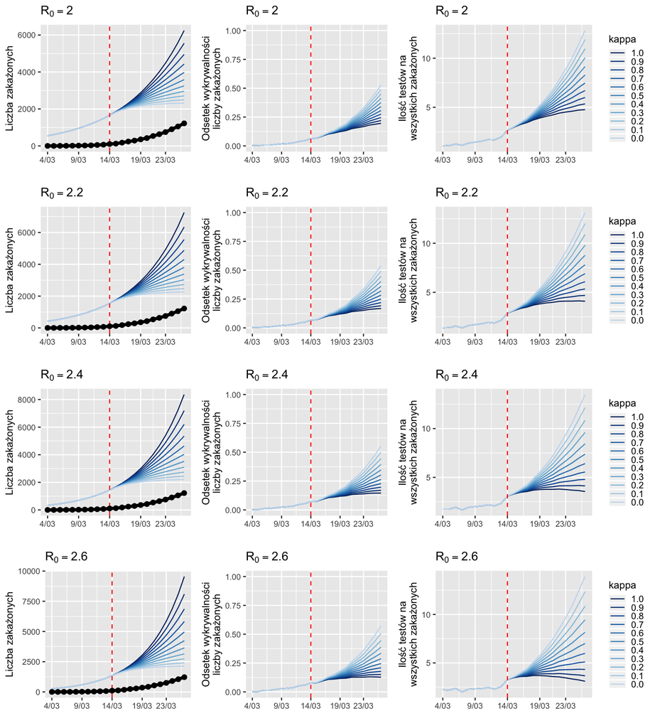

**Figure 3. Trendy w testowaniu i wykrywalności liczby zakażonych w Polsce.** Tabela wykresów pokazuje trendy w wykrywalności i testowaniu w czasie. Oś X reprezentuje czas (miesiąc roku 2020), a każdy rząd tabeli pokazuje wyniki dla innej zakładanej wartości $R_0$. Wykresy po lewej stronie pokazują liczbę raportowanych przypadków zakażonych (czarny) i prognozowaną rzeczywistą liczbę przypadków zakażonych dla różnych wartości $\kappa$ (odcienie niebieskiego), gdzie $\kappa=1$ odzwierciedla niezmienioną transmisję wirusa po interwencji, a $\kappa=0$ brak nowych zakażeń po interwencjach 14/03. Środkowe wykresy pokazują szacowany odsetek wykrywalności liczby zakażonych w czasie (stosunek liczby potwierdzonych przypadków do szacowanej liczby przypadków dla różnych wartości $\kappa$). Wykresy po prawej przedstawiają dzienną liczbę przeprowadzonych testów w stosunku do przewidywanej liczby przypadków zakażonych dla różnych wartości $\kappa$. (Proszę zwrócić uwagę, że większa liczba testów niż przewidywana liczba przypadków zakażonych nie oznacza, że przeprowadzana jest wystarczająca liczba testów, ponieważ ogromna większość osób testowanych ma wynik negatywny). Czerwona linia przerywana pokazuje czas wprowadzenia rządowych interwencji wprowadzających dystansowanie społeczne w dniu 14/03.

### 3. Jak dystansowanie społeczne wpłynie na pandemię COVID-19 w Polsce?

Jako że na razie nie można wiarygodnie oszacować skuteczności rządowych interwencji wprowadzających dystansowanie społeczne, $\kappa$, postanowiłem przedstawić różne scenariusze prognostyczne co do rozwoju pandemii COVID-19 w Polsce w najbliższych miesiącach w zależności od takiej skuteczności (patrz Ryc. 4). Założyłem przy tym najbardziej zakaźny scenariusz z rozważanych, a mianowicie $R_0=2.6$. Wyniki wskazują, że wynik epidemii będzie w ogromnym stopniu zależał od stopnia zakaźności wirusa wprowadzeniu interwencji. Nawet jeśli interwencje były tak skuteczne, że $R_0$ zostało zredukowane do poniżej 1 (fala epidemiologiczna zaczyna zanikać), czas zakończenia epidemii nadal będzie zależał od wartości $R_0$. Na przykład, jeśli $R_0$ został zredukowany do poniżej 0.5, fala epidemiologiczna powinna zanikać na początku lata; jeśli jednak $R_0$ osiągnie wartość między 0.5 a 1, okres zanikania może potrwać znacznie dłużej. Z drugiej strony jeśli nie uda nam się obniżyć $R_0$ poniżej 1, wpływ na zdrowie ludności i naszą służbę zdrowia może być ogromny, potencjalnie ryzykująć życie dziesiątek tysięcy osób lub nawet więcej do lata. Dlatego też symulacje te pokazują, że skuteczność rządowych działań na rzecz społecznego zdystansowania będzie odgrywać kluczową rolę w zapobieganiu tysiącom niepotrzebnych zgonów.

Skuteczne działania wprowadzające dystansowanie społecznie i wynikające z tego szybko zanikająca fala epidemii mają jednak drugą stronę medalu, ponieważ wtedy większość ludności byłaby nadal podatna na zakażenie. Jak pokazano na rycinie 4, duża liczba podatnych oznacza, że nie bylibyśmy w stanie dojść do poziomu tzw. “odporności stadnej” (ang. herd-immunity) wymaganego do zapobiegania przyszłym wybuchom epidemii COVID-19 w Polsce, a takie wybuchy mogłyby wystąpić po zupełnym odstąpieniu od rządowych działań na rzecz dystansowania społecznego. Dlatego też, dopóki szczepienia na COVID-19 nie staną się powszechnie dostępne, aby sztucznie wygenerować taki poziom odporności stadnej w populacji, należy rozważyć długoterminową strategię zapobiegania potencjalnym wybuchom epidemii COVID-19 w Polsce (np. poprzez alternatywne środki, takie jak testy serologiczne, tropienie kontaktów, proaktywną izolację itp.).

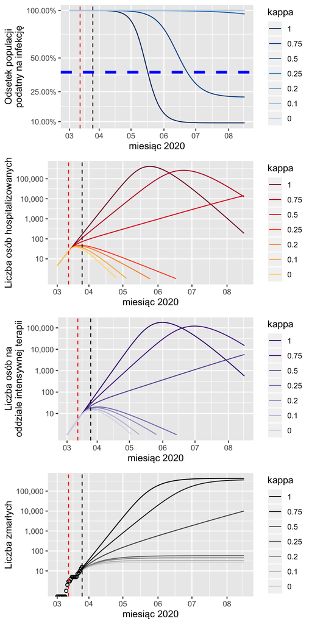

**Rycina 4. Prognozy pandemii COVID-19 w Polsce.** Prognozy rozwoju pandemii COVID-19 w Polsce w czasie w zależności od parametru $\kappa$, który odzwierciedla skuteczność interwencji rządowych (odcienie niebieskiego; im jaśniejszy kolor tym mniejsza zakaźność a więc skuteczniejsza interwencja). Górny panel pokazuje odestek populacji w Polsce podatnej na infekcję w czasie. Linia przerywana pokazuje maksymalny odsetek osób podatnych w populacji, $1/R_0$ (38% zakładając $R_0=2.6$), przy którym jesteśmy w stanie odeprzeć przyszłe wybuchy epidemii COVID-19 dzięki odporności stadnej - większy odsetek osób podatnych niż pokazany przez linię przerywaną otworzyłby drzwi nowym wybuchom epidemii. Drugi panel (czerwony) pokazuje ilość osób hospitalizowanych w czasie. Trzeci panel (filoetowy) pokazuje ilość osób przyjętych na oddział intensywnej terapii w czasie. Czwarty panel (czarny) pokazuje skumulowaną ilość osób zmarłych w czasie. Czerwona linia przerywana pokazuje datę wprowadzenia interwencji rządowych (14/03), a czarna linia pokazuje ostatni punkt danych, na podstawie których wykonana została obecna wersja raportu.

## Wnioski

Analiza ta opiera się na metodologii, która ma kilka istotnych ograniczeń. Po pierwsze, wszelkie przewidywania tego modelu są ograniczone przez jego właściwości, jak również przez parametry, które model ten wstępnie zakłada. Wartości parametrów oparte zostały na tych opisanych w literaturze naukowej, jednak ich wielkość będzie miała wpływ na przedstawione przewidywania ilościowe. Jednym z kluczowych przykładów jest śmiertelność (ang. case-fatality rate), przyjęty w analizie na poziomie 1.25%, który zgodnie z przewidywaniami będzie miał wpływ na szacunkową skalę niedoszacowania rzeczywistej liczby zakażeń. Należałoby zbadać, w jaki sposób wyniki różnią się, gdy przyjęty współczynnik śmiertelności jest niższy lub wyższy. Ogólnie, ważne jest, aby nie wykorzystywać proponowanej metody do wysuwania ilościowych wniosków na temat wpływu epidemii w przyszłości, lecz raczej do oceny wpływu niektórych założeń (np. ograniczenia transmisji wirusa poprzez dystansowanie społeczne narzucone przez rząd $\kappa$) na dynamikę epidemiologiczną.

Niemniej jednak, przewidywania jakościowe tej analizy nie są szczególnie zaskakujące dla każdego, kto na co dzień bada dynamikę chorób zakaźnych. Po pierwsze, epidemia w Polsce najprawdopodobniej rozpoczęła się kilka tygodni zanim pierwszy przypadek został odnotowany. Po drugie, obecnie podawane liczby zakażonych osób są prawdopodobnie znacznie zaniżone w stosunku do rzeczywistych, biorąc pod uwagę wciąż stosunkowo niewielką liczbę badań RT-PCR przeprowadzanych w Polsce w porównaniu z innymi krajami, takimi jak Korea Południowa (chociaż odsetek zgłaszanych przypadków jest obecnie niski w wielu krajach). Po trzecie, skuteczność rządowych działań na rzecz dystansowania społecznego będzie miała silny wpływ na przebieg epidemii. Na koniec, do czasu udostępnienia szczepionki przeciwko COVID-19, całkowita rezygnacja z dystansowania społecznego wiąże się z ryzykiem ponownego pojawienia się epidemii w Polsce. Ponieważ [mało prawdopodobne jest, że SARS-CoV-2 zupełnie zniknie wraz z nadchodzącą zmianą sezonową](https://ccdd.hsph.harvard.edu/will-covid-19-go-away-on-its-own-in-warmer-weather/), bardzo ważnym jest opracowanie dodatkowej strategii zapobiegania takim wybuchom w przyszłości.

Niniejsza analiza jest moja pierwszą próbą przewidzenia dynamiki epidemiologicznej COVID-19 w Polsce i będę otrzymywać komentarze od innych naukowców w tej dziedzinie. Kod jest dostępny dla wszystkich, każdy może go pobrać, zmodyfikować i wdrożyć własne udoskonalenia.

## Podziękowania

Dziękuję doktorowi Christianowi Althausowi za publiczne udostępnienie swojej metodologii, Krzysztofowi Słomczyńskiemu za pomoc w problemami technicznymi z R Markdownem oraz Stowarzyszeniowi Rzecznicy Nauki za pomoc w komunikacji wyników raportu.